# Lecture 06 Exercise — Cross-validation and the bootstrap with tidymodels

PubH 6010 Independent Study · UCI Beijing PM2.5 data

Your name: Katie O’Brien

2026-10-14

# 1 Overview

This exercise redoes the Lecture 06 R examples on an air-pollution dataset, using **tidymodels** instead of caret. caret is no longer actively developed; its author (Max Kuhn) now leads tidymodels, which is the current standard for modeling in R. Every task maps to a slide, so you can follow the lecture’s logic and translate the code.

| caret (slides) | tidymodels |
| --- | --- |
| `train(x, y, method = "lm")` | `workflow()` + `recipe()` + `linear_reg()` |
| (single random split, slide 7) | `initial_validation_split()` + `validation_set()` |
| `trainControl(method = "LOOCV")` | `vfold_cv(data, v = nrow(data))` |
| `trainControl(method = "cv", number = 10)` | `vfold_cv(data, v = 10)` |
| `train(..., tuneGrid = ...)` | `tune_grid(workflow, resamples, grid = ...)` |
| `$results`, `$bestTune` | `collect_metrics()`, `select_best()` |
| `twoClassSummary` | `metric_set(roc_auc, sens, spec)` |
| `thresholder()` | `probably::threshold_perf()` |
| (manual bootstrap loop) | `bootstraps()` + `int_pctl()` |

Install once: `install.packages(c("tidymodels", "kknn", "probably"))`. The resources at https://www.tidymodels.org/start/ (especially “Evaluate your model with resampling” and “Tune model parameters”) and the free book *Tidy Modeling with R* (https://www.tmwr.org, chapters 10 and 13) cover everything used here.

**Data.** `beijing_pm25_2014.csv` holds daily PM2.5 and weather at the U.S. Embassy in Beijing for 2014 (360 days), built from the UCI Machine Learning Repository’s *Beijing PM2.5 Data* (dataset 381). `prepare_beijing_daily.R` shows how the hourly file was turned into daily values.

> Liang X, Zou T, Guo B, Li S, Zhang H, Zhang S, Huang H, Chen SX. Assessing Beijing’s PM2.5 pollution: severity, weather impact, APEC and winter heating. *Proc R Soc A.* 2015;471:20150257.

| Column | Meaning |
| --- | --- |
| `pm25` | Daily mean PM2.5 (µg/m³) |
| `log_pm25` | log(`pm25`): **regression outcome** |
| `exceed` | `Yes` if `pm25` > 75 µg/m³ (China’s 24-h Grade II standard): **classification outcome** |
| `dewp`, `temp` | Daily mean dew point and temperature (°C) |
| `pres` | Daily mean air pressure (hPa) |
| `wind_max` | Highest cumulated wind speed reached that day (m/s); larger = stronger, more sustained wind |
| `rain_hours` | Hours with rain |
| `wind_dir` | Most frequent wind direction (`NE`, `NW`, `SE`, `cv` = calm/variable) |
| `date`, `month`, `season` | Calendar variables. **Not** used as predictors |

**Predictors used throughout:** `dewp`, `temp`, `pres`, `wind_max`, `rain_hours`, `wind_dir`.

Submit your knitted `.Rmd` with short written answers to the questions in **bold**.

# 2 Tasks

## 2.1 Part A — Look at the data and set up a workflow

1. Read the data, make `wind_dir` a factor, and make `exceed` a factor with levels `c("Yes", "No")`, **in that order** (Part E explains why).
2. Plot histograms of `pm25` and `log_pm25`, and count how many days exceed 75 µg/m³.
3. Build a **recipe** for `log_pm25` on the six predictors with `step_dummy(wind_dir)`. Combine it with `linear_reg()` in a **workflow**.

```r
library(tidyverse)
library(tidymodels)
tidymodels_prefer()

beijing <- read_csv("beijing_pm25_2014.csv", show_col_types = FALSE) |>
  mutate(wind_dir = factor(wind_dir),
         exceed   = factor(exceed, levels = c("Yes", "No")))

(exceed_summary <- beijing %>%
  group_by(exceed) %>%
  summarize(count = n()) %>%
  mutate(proportion = count / sum(count)) %>%
  ungroup())
```

```
## # A tibble: 2 × 3
##   exceed count proportion
##   <fct>  <int>      <dbl>
## 1 Yes      185      0.514
## 2 No       175      0.486
```

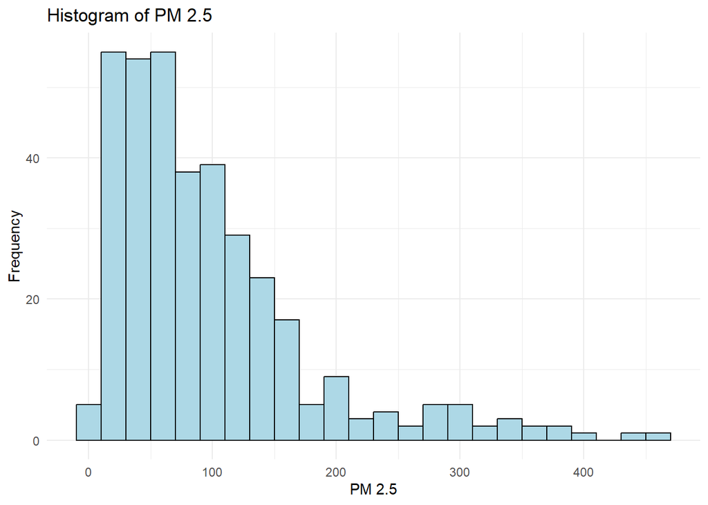

```r
ggplot(beijing, aes(x = pm25)) +
  geom_histogram(binwidth = 20, color = "black", fill = "lightblue") +
  labs(title = "Histogram of PM 2.5", x = "PM 2.5", y = "Frequency") +
  theme_minimal()
```

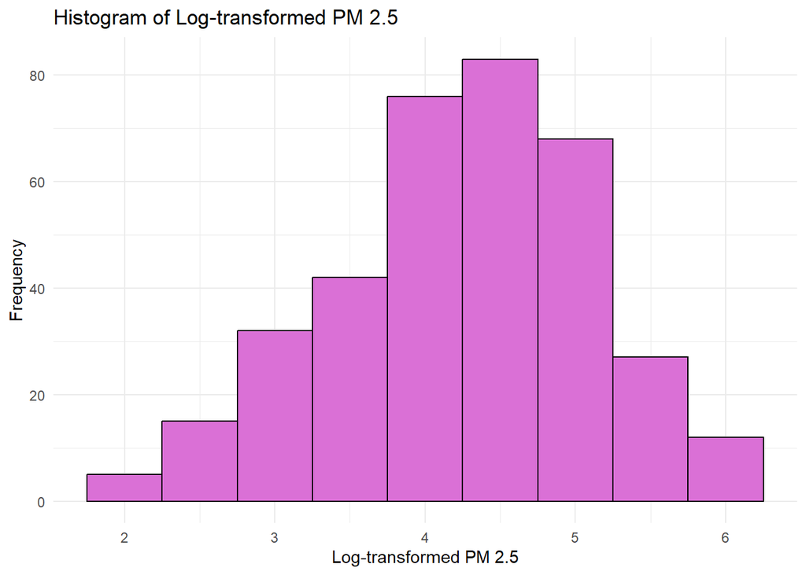

```r
ggplot(beijing, aes(x = log_pm25)) +
  geom_histogram(binwidth = 0.5, color = "black", fill = "orchid") +
  labs(title = "Histogram of Log-transformed PM 2.5", x = "Log-transformed PM 2.5", y = "Frequency") +
  theme_minimal()
```

```r
# Part A: recipe + workflow
reg_rec <- recipe(log_pm25 ~ dewp + temp + pres + wind_max + rain_hours + wind_dir, data = beijing) |>
  step_dummy(wind_dir)
lm_wf <- workflow() |> add_recipe(reg_rec) |> add_model(linear_reg())
```

> **Q1.** Why do we model `log_pm25` rather than `pm25`? What proportion of days exceed the standard?

We model PM 2.5 log-transformed because it is normally distributed. The original distribution of PM 2.5 is right skewed. The proportion of days exceeding the standard is 0.51.

## 2.2 Part B — The validation-set approach (slides 7–9)

4. After `set.seed(1)`, use `initial_validation_split(beijing, prop = c(0.5, 0.25))` to split the data **once** into training (50%), validation (25%) and testing (25%). Print the split to check the sizes.
5. Turn the split into a resample with `validation_set()`. Then run `fit_resamples()` with `metrics = metric_set(rmse)`: this fits on the training set and scores on the validation set. Square the RMSE to get the validation MSE.

The testing set is held back and is not used this week. In practice it is touched once, at the very end, to evaluate the final model (`last_fit()`).

```r
# Part B: one validation split (training 50% / validation 25% / testing 25%)
set.seed(1)
beijing_split <- initial_validation_split(beijing, prop = c(0.5, 0.25))
beijing_split
```

```
## <Training/Validation/Testing/Total>
## <180/90/90/360>
```

```r
# turnng the split into a resample
val_set <- validation_set(beijing_split)

# this fits on the training set and scores on the validation set
fit_resamples(lm_wf, resamples = val_set, metrics = metric_set(rmse)) |>
  collect_metrics()
```

```
## # A tibble: 1 × 6
##   .metric .estimator  mean     n std_err .config
##   <chr>   <chr>      <dbl> <int>   <dbl> <chr>
## 1 rmse    standard   0.718     1      NA pre0_mod0_post0
```

> **Q2.** What is your validation-set estimate of the test MSE? Compare it with the LOOCV and 10-fold estimates you get in Part C. Using slides 8–9, give two reasons why a single validation split can be a poor estimate of the test error of a model fit to all the data.

The validation-set estimate of the MSE is 0.717^2 = 0.51. A single validation split can be a poor estimate of the test error of a model because it can vary substantially, and by running the model only once, you are likely to get a biased estimate.

## 2.3 Part C — LOOCV and 10-fold CV for linear regression (slides 26–28, 32)

6. **LOOCV.** `tune` does not accept `loo_cv()`, so use `vfold_cv(beijing, v = nrow(beijing))`. Run `fit_resamples()` with `control = control_resamples(save_pred = TRUE)`.
7. Compute the LOOCV RMSE **two ways**: (a) `collect_metrics()`, and (b) `collect_predictions() |> rmse(truth = log_pm25, estimate = .pred)`. Square (b) to get the LOOCV MSE.
8. Check (b) against the slide 13 shortcut, which needs only one `lm()` fit: `mean((residuals(fit) / (1 - hatvalues(fit)))^2)`.
9. **10-fold CV:** After `set.seed(12345)`, create `vfold_cv(beijing, v = 10)`, run `fit_resamples()`, and look at `collect_metrics()`. Square the mean RMSE to get the 10-fold MSE. Then check how much this answer depends on the random assignment of days to folds: redo the 10-fold CV with seeds 1, 2, 3, 4 and 5 (each seed puts different days in each fold) and record the five MSEs.

```r
# Part C: LOOCV and 10-fold cv
# loo_folds <- vfold_cv(beijing, v = nrow(beijing))
# lm_loo <- fit_resamples(lm_wf, resamples = loo_folds, metrics = metric_set(rmse),
                       # control = control_resamples(save_pred = TRUE))
# collect_metrics(lm_loo3)                                           # (a)
# collect_predictions(lm_loo) |> rmse(truth = log_pm25, estimate = .pred)   # (b)
# vfold_cv doesn't work with LOOCV, so need to use loo_cv
# loo_folds2 <- loo_cv(beijing)
# lm_loo2 <- fit_resamples(lm_wf, resamples = loo_folds2, metrics = metric_set(rmse),
                       # control = control_resamples(save_pred = TRUE))

# tune doesn't work with LOOCV, so need to use caret
library(caret)
loo_folds3 <- trainControl(method = "LOOCV")
lm_loo3 <- train(
  log_pm25 ~.,
  data = beijing,
  method = "lm",
  trControl = loo_folds3
)
print(lm_loo3$results)
```

```
##   intercept      RMSE  Rsquared      MAE
## 1      TRUE 0.3050865 0.8706245 0.224152
```

```r
# 10 fold CV
set.seed(12345)
folds10 <- vfold_cv(beijing, v = 10)
lm_10 <- fit_resamples(lm_wf, resamples = folds10, metrics = metric_set(rmse))
collect_metrics(lm_10)
```

```
## # A tibble: 1 × 6
##   .metric .estimator  mean     n std_err .config
##   <chr>   <chr>      <dbl> <int>   <dbl> <chr>
## 1 rmse    standard   0.615    10  0.0186 pre0_mod0_post0
```

> **Q3.** Why do (a) and (b) in step 7 differ? (Hint: what is the RMSE of a single observation?) Which one matches the shortcut in step 8? How do the 10-fold estimates compare with LOOCV and with each other? What does the `std_err` column from `collect_metrics()` correspond to on slide 17?

The RMSE of a single observation is just the absolute value of the residual for that observation. The MSE for LOOCV is 0.30^2 = 0.09 while the MSE for the 10-fold CV is 0.61^2 = 0.38. The standard error column corresponds to the estimate standard error of the cross-validation.

## 2.4 Part D — Choosing K for KNN regression (slides 29–34)

10. Specify `nearest_neighbor(neighbors = tune(), weight_func = "rectangular")` with `set_engine("kknn")` and `set_mode("regression")`. (`"rectangular"` gives the classic, unweighted KNN from the lecture.)
11. Make a workflow whose recipe adds `step_normalize(all_numeric_predictors())` after `step_dummy()`.
12. Use `tune_grid()` with `grid = tibble(neighbors = 1:20)`, once on the LOOCV folds (with `save_pred = TRUE`; compute pooled RMSE per K as in step 7b) and once on the 10-fold folds.
13. Plot RMSE against K for both, as on slide 30, with a horizontal line at the linear regression’s LOOCV RMSE. Find the best K with `select_best()`, then `finalize_workflow()` and `fit()` it on all 360 days.

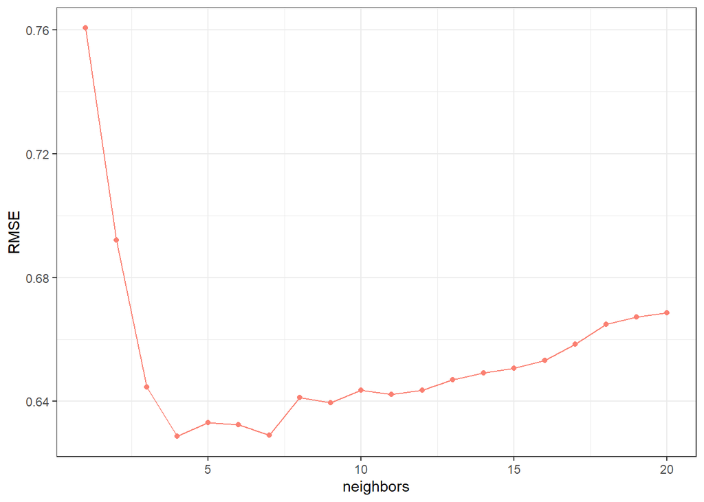

```r
# Part D: KNN, tuning K
library(tidymodels)
# KNN
knn_spec <- nearest_neighbor(neighbors = tune(), weight_func = "rectangular") |>
  set_engine("kknn") |>
  set_mode("regression")

# making workflow
knn_wf <- workflow() |>
  add_recipe(reg_rec |> step_normalize(all_numeric_predictors())) |>
  add_model(knn_spec)

set.seed(12345)
folds10 <- vfold_cv(beijing, v = 10)

# using tune grid
knn_10 <- tune_grid(knn_wf, resamples = folds10, grid = tibble(neighbors = 1:20),
                    metrics = metric_set(rmse))
# tune takes the workflow, resamples gives the folds, grid is the parameter you are tuning (tuning the number of nearest neighbors here)

# plot RMSE
collect_metrics(knn_10) |> ggplot(aes(neighbors, mean)) +
  geom_point(col = "salmon") + geom_line(col = "salmon") + labs(y = "RMSE") + theme_bw()
```

```r
select_best(knn_10, metric = "rmse")
```

```
## # A tibble: 1 × 2
##   neighbors .config
##       <int> <chr>
## 1         4 pre0_mod04_post0
```

> **Q4.** Which K does CV choose? Why is scaling essential for KNN (look at the ranges of `pres` and `wind_max`) but irrelevant for linear regression? Which model would you use to predict PM2.5, linear regression or the best KNN, and why?

K = 4 achieved the lowest RMSE. Scaling is necessary for KNN because features with larger scales would dominate calculations. RMSE is slightly lower with linear regression, so I would choose linear regression.

## 2.5 Part E — CV for classification (slides 35–39)

14. Build a recipe and workflow for `exceed` with `logistic_reg()`.
15. With 10-fold CV (`set.seed(1234)`), run `fit_resamples()` with `metrics = metric_set(accuracy, kap, roc_auc, sens, spec)` and `save_pred = TRUE`.
16. Use `probably::threshold_perf()` on `collect_predictions()` with thresholds 0.1, 0.2, …, 0.9 and `metrics = metric_set(sens, spec, accuracy)`.

```r
# Part E: logistic regression

# workflow
cls_rec  <- recipe(exceed ~ dewp + temp + pres + wind_max + rain_hours + wind_dir, data = beijing) |>
  step_dummy(wind_dir)
logit_wf <- workflow() |> add_recipe(cls_rec) |> add_model(logistic_reg())

# metrics
set.seed(1234)
cls_folds <- vfold_cv(beijing, v = 10)
logit_res <- fit_resamples(logit_wf, resamples = cls_folds,
                           metrics = metric_set(accuracy, kap, roc_auc, sens, spec),
                           control = control_resamples(save_pred = TRUE))

# threshold
probably::threshold_perf(collect_predictions(logit_res), truth = exceed, estimate = .pred_Yes,
                         thresholds = seq(0.1, 0.9, by = 0.1),
                         metrics = metric_set(sens, spec, accuracy, kap))
```

```
## # A tibble: 36 × 4
##    .threshold .metric .estimator .estimate
##         <dbl> <chr>   <chr>          <dbl>
##  1        0.1 sens    binary         0.989
##  2        0.2 sens    binary         0.946
##  3        0.3 sens    binary         0.903
##  4        0.4 sens    binary         0.832
##  5        0.5 sens    binary         0.751
##  6        0.6 sens    binary         0.643
##  7        0.7 sens    binary         0.514
##  8        0.8 sens    binary         0.324
##  9        0.9 sens    binary         0.173
## 10        0.1 spec    binary         0.154
## # ℹ 26 more rows
```

```r
collect_predictions(logit_res) |>
  roc_auc(truth = exceed, .pred_Yes)
```

```
## # A tibble: 1 × 3
##   .metric .estimator .estimate
##   <chr>   <chr>          <dbl>
## 1 roc_auc binary         0.801
```

> **Q5.** Report the CV accuracy, kappa, AUC, sensitivity and specificity. yardstick treats the **first** factor level as the event. What does `sens` mean with our level order? What would it mean with alphabetical order (`No`, `Yes`), as in the slide 38 example, and which argument fixes it? If this model were used to warn sensitive groups about high-pollution days, which threshold would you pick, and why?

With level order, sensitivity measures the ability to correctly identify true positives. With alphabetical order, sensitivity would measure the ability to correctly identify an outcome of “no”. The argument that fixes is estimate = .pred_Yes. If the model were used to warn sensitive gropus about high polution days, I would pick the 0.5 threshold because it has a good balance between sensitivity, specificity, and accuracy.

## 2.6 Part F — The bootstrap (slides 41–43)

17. Create `bootstraps(beijing, times = 1000)` (after `set.seed(2026)`).
18. For each bootstrap sample (`analysis(split)`), compute a small tibble with two rows (`term`, `estimate`):
    - the `wind_max` coefficient from `lm()`, and
    - the 90th percentile of `pm25`.
19. Get 95% percentile CIs with `int_pctl()`. Get bootstrap SEs by unnesting and taking the SD. Compare the coefficient’s bootstrap SE with the SE from `tidy(lm(...))`.

```r
# Part F: bootstrap
f_reg <- log_pm25 ~ dewp + temp + pres + wind_max + rain_hours + wind_dir
set.seed(2026)
boots <- bootstraps(beijing, times = 1000)

# tibble
boot_stats <- boots |>
  mutate(stats = map(splits, function(s) {
    d <- analysis(s)
    bind_rows(
      tidy(lm(f_reg, data = d)) |> filter(term == "wind_max") |> select(term, estimate),
      tibble(term = "p90", estimate = unname(quantile(d$pm25, 0.9)))
    )
  }))

# 95% percentiles CIs
int_pctl(boot_stats, stats)
```

```
## # A tibble: 2 × 6
##   term        .lower .estimate    .upper .alpha .method
##   <chr>        <dbl>     <dbl>     <dbl>  <dbl> <chr>
## 1 p90      168.      197.      245.        0.05 percentile
## 2 wind_max  -0.00373  -0.00245  -0.00117   0.05 percentile
```

> **Q6.** Do the two SEs for the coefficient agree? Why is the bootstrap useful for the 90th percentile in particular (slide 41)?